# InveRness RUG - Intro to ggplot2

## Better!

[figure not shown]

## Themes

## change the theme

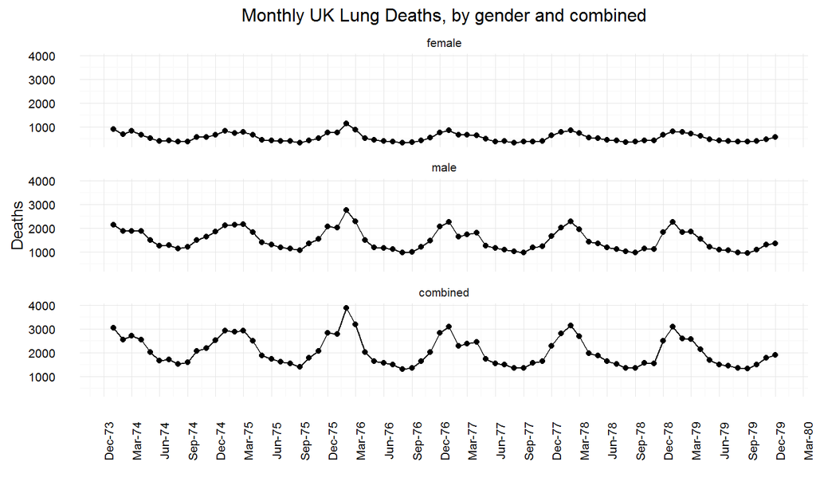

```r
p<-p+theme_minimal(base_size = 10)+
  theme(axis.text.x = element_text(angle = 90))
p
```

## From ggthemes package - Economist

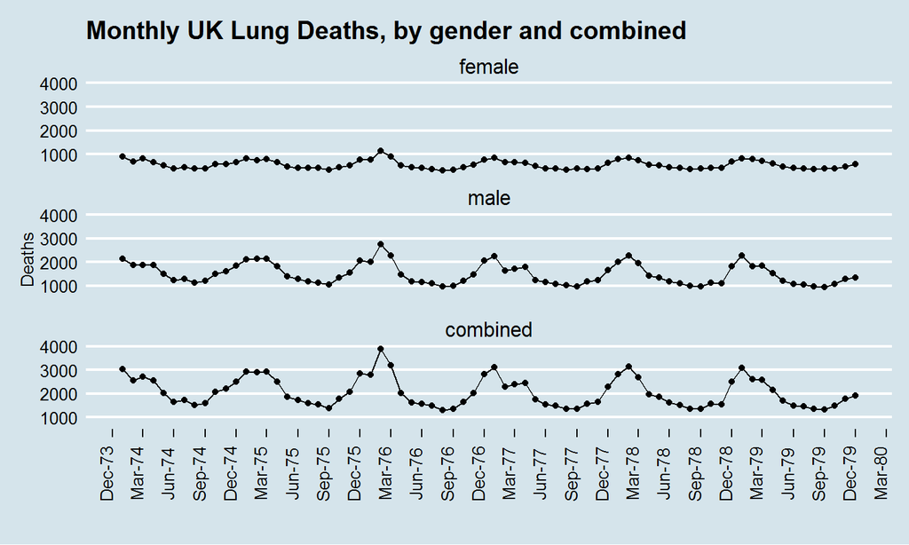

```r
p<-p+theme_economist(base_size = 10)+
 theme(axis.text.x = element_text(angle = 90))

p
```

## Some more themes:

-theme_stata() :stats package theme  
-theme_fivethirtyeight() : nate silver & co website -theme_wsj() :Wall Street Journal  
-theme_few () :inspired by work of data vis guru Stephen Few -theme_gdocs() :google docs

## More on aesthetics..

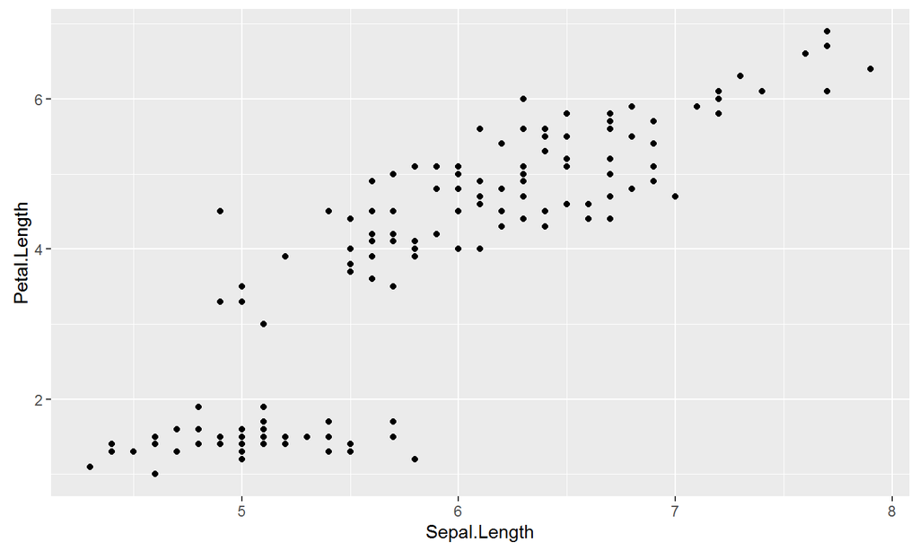

```r
ggplot(iris,aes(Sepal.Length,Petal.Length))+geom_point()
```

## Map Species

- here the colour mapping goes inside the aes()brackets

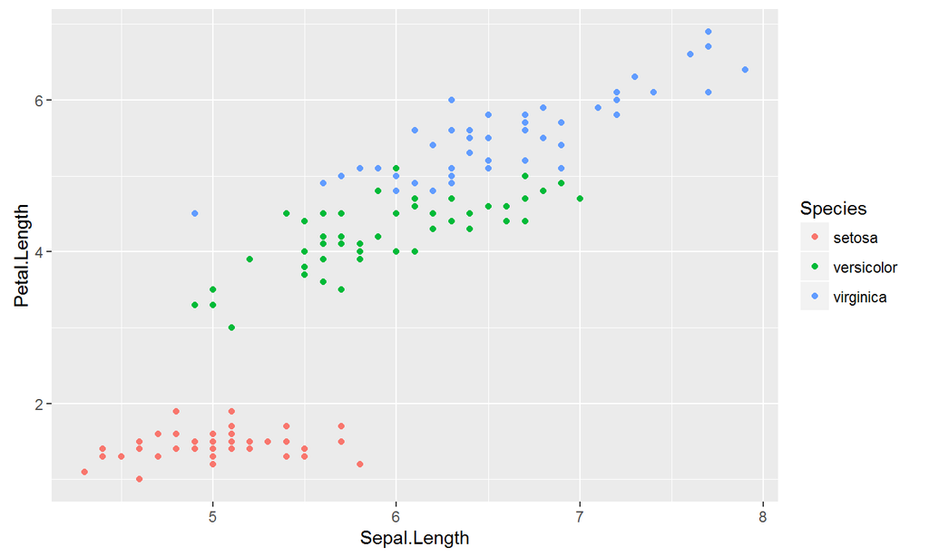

```r
p<-ggplot(iris,aes(Sepal.Length,Petal.Length,colour= Species))+geom_point()
 p
```

## Can add aesthetics to the geom instead:

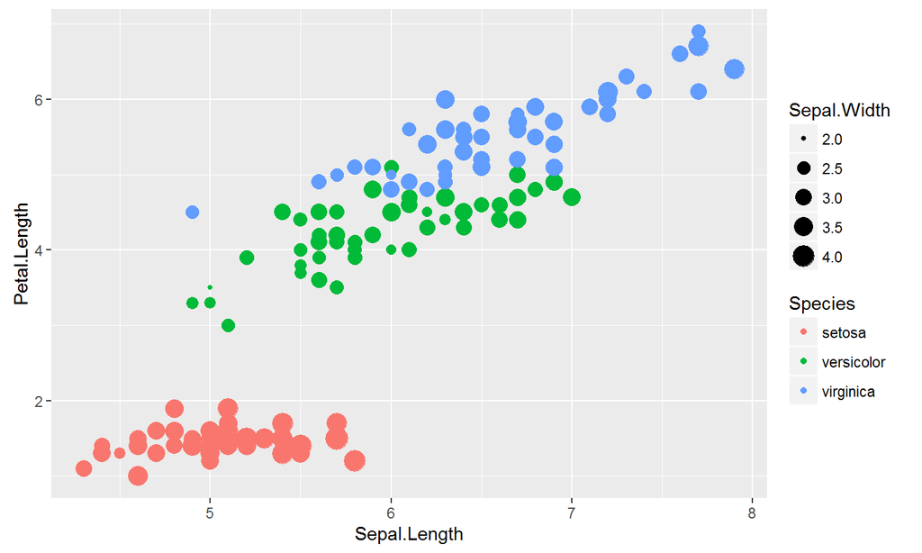

```r
p<-ggplot(iris,aes(Sepal.Length,Petal.Length))+
  geom_point(aes(colour= Species,size=Sepal.Width))
p
```

## Make the points more transparent

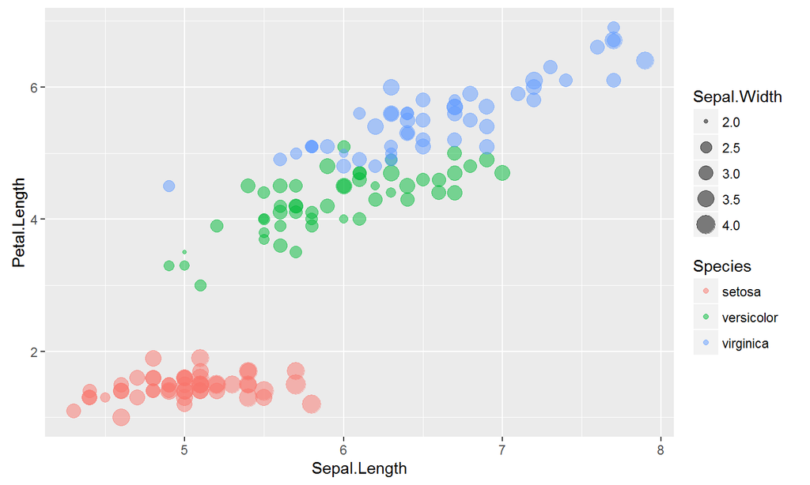

```r
p<-ggplot(iris,aes(Sepal.Length,Petal.Length))+
  geom_point(aes(colour= Species,size=Sepal.Width),alpha=0.5)
p
```

## Add line of best fit

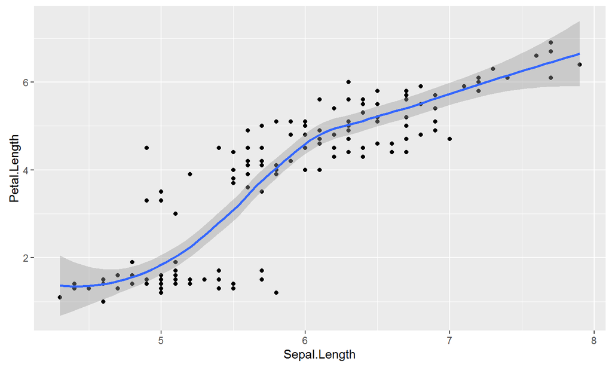

```r
p<-ggplot(iris,aes(Sepal.Length,Petal.Length))+geom_point()
p<- p + geom_smooth()
p
```

## Individual plots

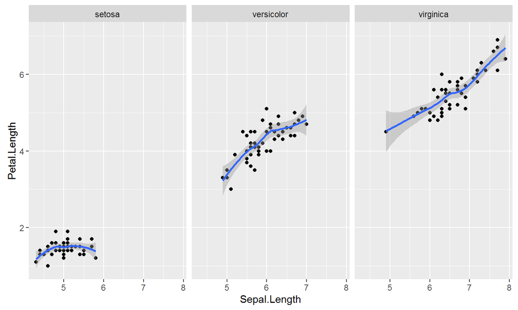

```r
 p<- p +facet_grid(.~Species)
p
```

## What you learned

- aesthetics: define the x,y coordinates

but also,

- size
- shape
- colour

Results in ability to create more complex plots

## Things to bear in mind

- aesthetics applied to the geom layer only apply to that geom
- aesthetics added in the initial aes(x,y) call apply to all geoms,unless over-written

```r
geom_point(aes(colour=Species))
```

produces similar plot to:

```r
aes(Sepal.Length,Petal.Length,colour= Species))+geom_point()
```

```r
geom_point(colour="blue")
```

will colour all points blue, but:

```r
geom_point(aes(colour="blue"))
```

might not work as intended

## Boxplots

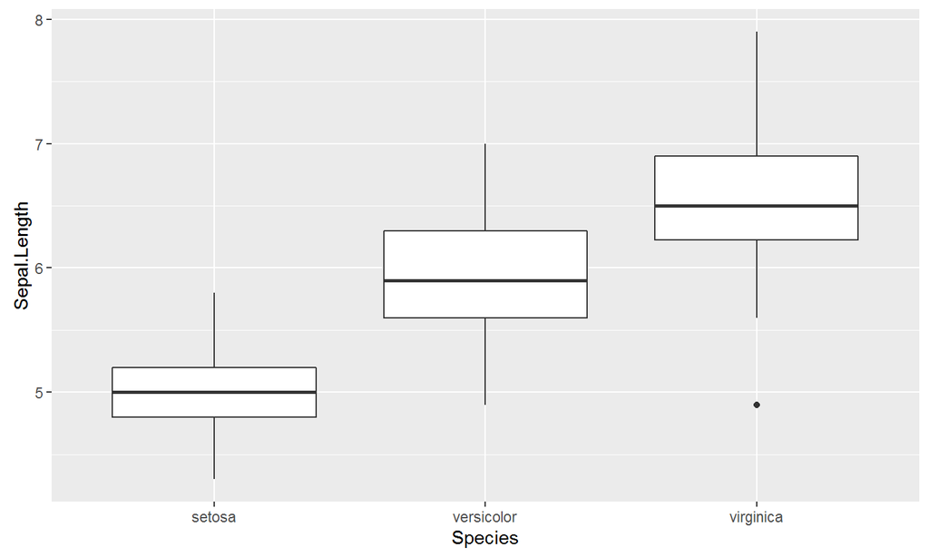

```r
ggplot(iris,aes(x=Species,y=Sepal.Length))+geom_boxplot()
```

## Narrower

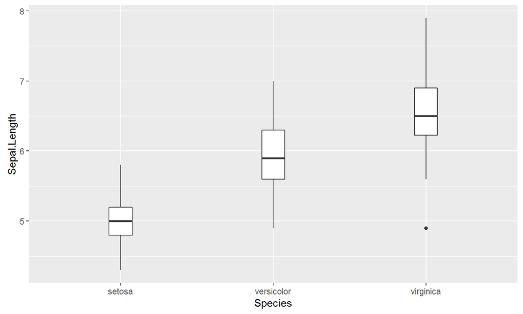

```r
ggplot(iris,aes(x=Species,y=Sepal.Length))+
geom_boxplot(width=0.2)
```

## Alternative

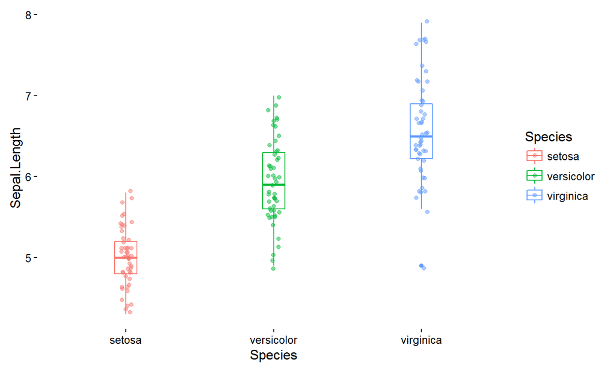

```r
ggplot(iris,aes(x=Species,y=Sepal.Length,colour=Species))+
geom_boxplot(width=0.2)+
geom_jitter(position=position_jitter(0.1),alpha=0.5)+
theme_classic()
```

## Other packages to note

## ggplot2 plays well with:

- dplyr # peform sql operations and more
- tidyr # reshape data
- broom # turn objects from other packages and code into data frames
- RColorBrewer # nice colour palettes
- lubridate # working with dates

## Other useful packages:

- ggGally : survival curves
- ggmap : mapping e.g. http://spatial.ly/2015/03/mapping-flows/
- ggthemes
- ggvis : interactive Grammar of Graphics
- ggExtra : extra ggplots and useful functions:
- cowplot - clean plots using ggplot -saves coding time
- RODBC: connect to databases for data import/export

## Closing examples:

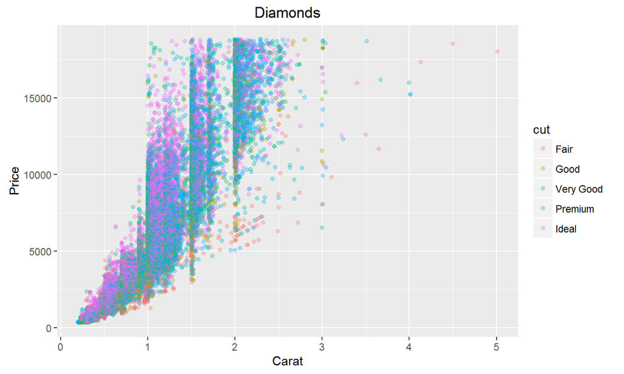

```r
g <- ggplot(diamonds, aes(x=carat, y=price, color=cut)) + geom_point(alpha=0.3) +
labs(title="Diamonds", x="Carat", y="Price")
print(g)
```

## Add titles and format

```r
g1<-g+theme(plot.title=element_text(size=15, face="bold"),
                  axis.text.x=element_text(size=8),
                  axis.text.y=element_text(size=8),
                  axis.title.x=element_text(size=10),
                  axis.title.y=element_text(size=10)) +
  scale_color_discrete(name="Cut of diamonds")
print(g1)
```

## Results

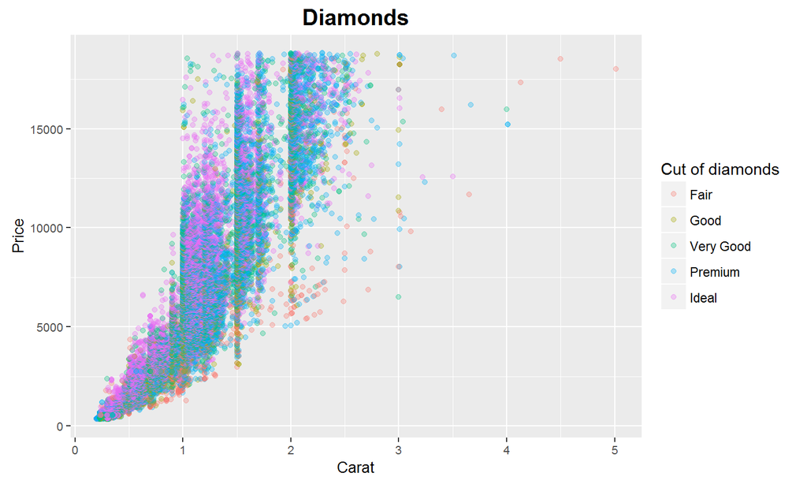

## Facet

```r
g2<-g1 + facet_grid(color ~ cut)
g2
```

## Results

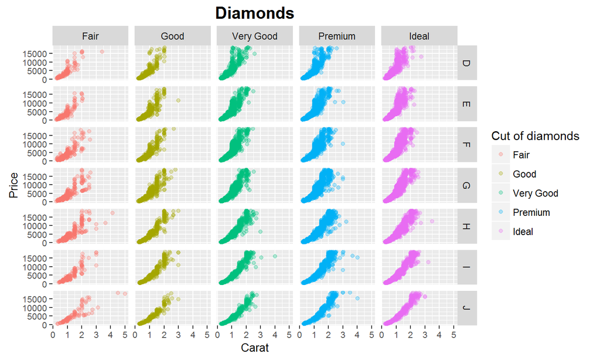

## coord_cartesian

zooms in, doesn't delete or distort

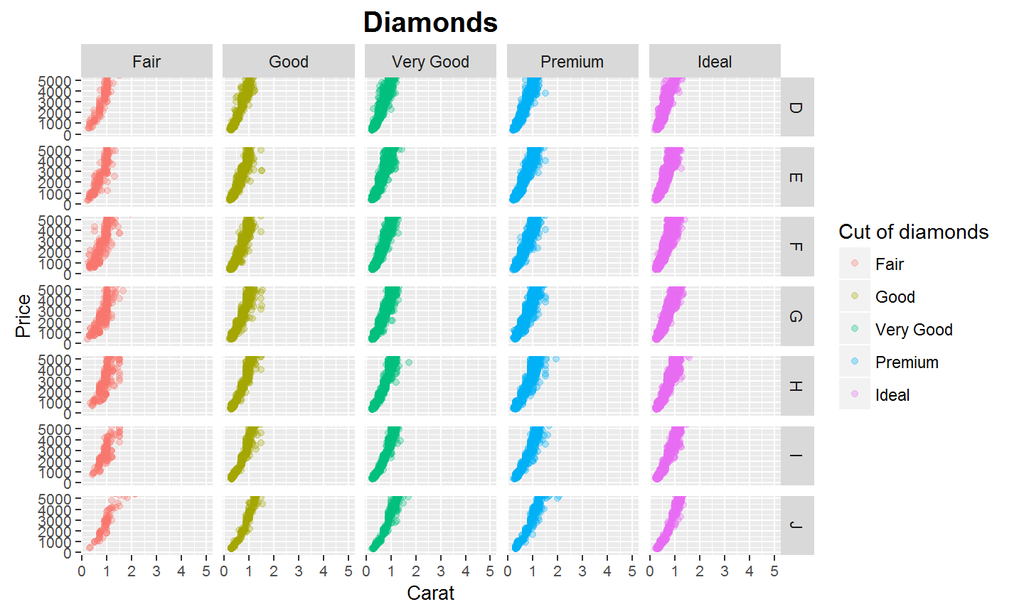

```r
g3<- g2 + coord_cartesian(ylim=c(0,5000))
g3
```

## dplyr & ggplot = awesome:

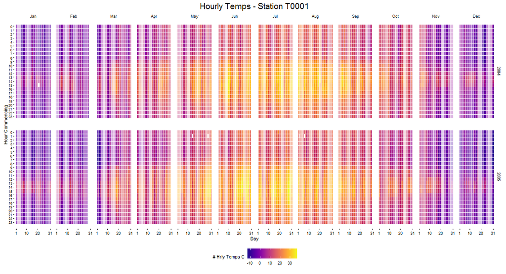

Temperature by hour, by day, by month over 2 years, from specified weather station

## Help?

- Help : http://stackoverflow.com
- Subscribe : http://r-bloggers.com

## Thanks for listening!

John MacKintosh  
dataguy.jm@gmail.com  
@HighlandDataSci  
https://github.com/johnmackintosh  
http://johnmackintosh.com